# Tarea 2: descenso en gradiente

```r
library(tidyverse)
```

En el siguiente problema queremos predecir el porcentaje de grasa corporal (que es relativamente costoso de medir) en términos de distintas medidas del cuerpo (estatura, peso, circunferencia de abdomen, etc.) Usaremos [estos datos](http://jse.amstat.org/v4n1/datasets.johnson.html). Las medidas corporales están estandarizadas.

```r
bodyfat <- read_csv('../datos/bodyfat_est.csv')
```

Vamos a ajustamos un modelo lineal de la forma:

$grasacorp ~ b_0 + b_1 estatura + b_2 abdomen + b_3 muñeca + b_4 rodilla$

### Parte 1: separar muestra de entrenamiento y de prueba:

Separa los datos a la mitad: 50% de entrenamiento y 50% de prueba aproximadamente:

```r
set.seed(92311)
bodyfat$id <- 1:nrow(bodyfat)
bodyfat$unif <- runif(nrow(bodyfat), 0, 1)
dat_ent <- bodyfat %>% filter(unif < 0.5)
dat_pr <- bodyfat %>% filter(unif >= 0.5)
dim(dat_ent)
```

```
## [1] 118  16
```

```r
dim(dat_pr)
```

```
## [1] 134  16
```

**Pregunta**: ¿Por qué en este ejemplo no sería buena idea tomar, por ejemplo, 90% de datos para entrenamiento y 10% para prueba?

### Parte 2: Calcula algunos resúmenes de los datos de entrenamiento

Calcula al menos mínimo, máximo y algunos percentiles para las variables *estatura*, *abdomen*, *muñeca*, *rodilla* y *grasacorp*. Por ejemplo:

```r
quantile(dat_ent$muñeca)
```

```
##          0%         25%         50%         75%        100%
## -2.60261475 -0.67456306  0.02167783  0.61080474  3.39576829
```

```r
print("estatura")
```

```
## [1] "estatura"
```

```r
summary(dat_ent$estatura)
```

```
##     Min.  1st Qu.   Median     Mean  3rd Qu.     Max.
## -11.0976  -0.5866  -0.1089  -0.1176   0.5054   1.5974
```

```r
print("abdomen")
```

```
## [1] "abdomen"
```

```r
summary(dat_ent$abdomen)
```

```
##     Min.  1st Qu.   Median     Mean  3rd Qu.     Max.
## -2.14744 -0.63581 -0.15821  0.06334  0.68571  5.15104
```

```r
print("muñeca")
```

```
## [1] "muñeca"
```

```r
summary(dat_ent$muñeca)
```

```
##     Min.  1st Qu.   Median     Mean  3rd Qu.     Max.
## -2.60262 -0.67456  0.02168  0.00080  0.61081  3.39577
```

```r
print("rodilla")
```

```
## [1] "rodilla"
```

```r
summary(dat_ent$rodilla)
```

```
##     Min.  1st Qu.   Median     Mean  3rd Qu.     Max.
## -2.31796 -0.76311  0.02468  0.06403  0.65699  4.35754
```

```r
print("grasacorp")
```

```
## [1] "grasacorp"
```

```r
summary(dat_ent$grasacorp)
```

```
##    Min. 1st Qu.  Median    Mean 3rd Qu.    Max.
##    0.00   12.65   19.90   19.84   25.95   38.10
```

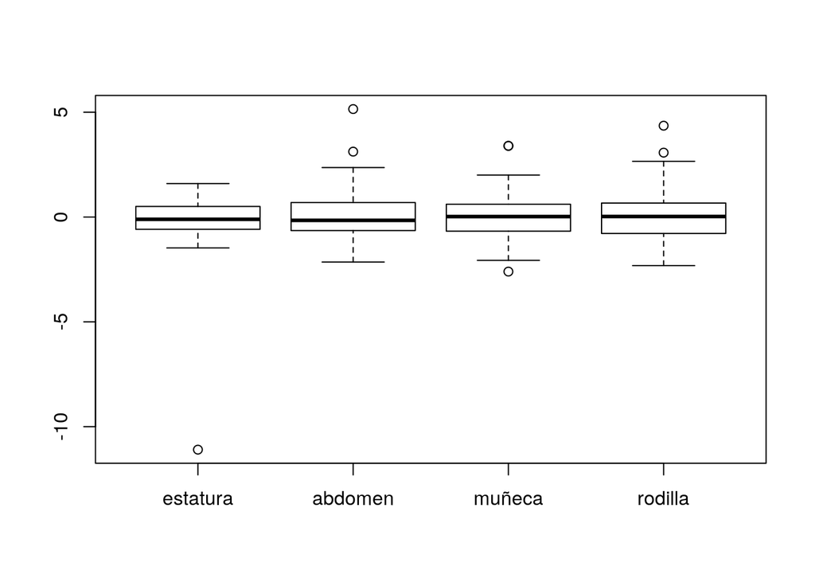

```r
boxplot(dat_ent[c("estatura","abdomen","muñeca","rodilla")])
```

Puedes usar estas funciones, o escribir el código tu mismo:

```r
error_calc <- function(x, y){
  # x es un data.frame o matrix con entradas
  # y es la respuesta
  error_fun <- function(beta){
    # esta funcion debe devolver rss
    y_hat <- as.matrix(cbind(1,x)) %*% beta
    # residual
    e <- y - y_hat
    error <- 0.5*mean(e^2) ##PORQUE 0.5??
    error
  }
  error_fun
}


grad_calc <- function(x, y){
  # devuelve una función que calcula el gradiente para
  # parámetros beta
  # x es un data.frame o matrix con entradas
  # y es la respuesta
  grad_fun <- function(beta){
      # para este cálculo, ver notas
      f_beta <- as.matrix(cbind(1, x)) %*% beta
      e <- y - f_beta
      gradiente <- - apply(t(cbind(1,x)) %*% e, 1, mean) #El 1/N REALMENTE NO ES PARTE DE LA DERIVDA ??
      names(gradiente)[1] <- 'Intercept'
      gradiente
    }
   grad_fun
}


descenso <- function(n, z_0, eta, h_grad){
  # esta función calcula n iteraciones de descenso en gradiente
  z <- matrix(0,n, length(z_0))
  z[1, ] <- z_0
  for(i in 1:(n-1)){
    z[i+1,] <- z[i,] - eta * h_grad(z[i,])
  }
  z
}
```

```r
x_ent <- dat_ent %>% select(estatura, abdomen, muñeca, rodilla)
x_pr <- dat_pr %>% select(estatura, abdomen, muñeca, rodilla)
y_ent <- dat_ent$grasacorp
y_pr <- dat_pr$grasacorp
```

**Pregunta**: Rellena el siguiente código:

```r
gradiente <- grad_calc(x_ent , y_ent )
error <- error_calc(x_ent , y_ent )
```

**Pregunta**: ¿cuál es un valor de número de iteraciones (n) y tamaño de paso (eta) para este problema? ¿Qué pasa si haces eta demasiado grande? Si eta es demasiado grande, el metodo divergerá, parece que con 45 iteraciones el método converge

Ahora **selecciona un valor del tamaño de paso** y corre descenso en gradiente:

```r
n <- 45### rellena aquí un valor apropiado
eta <- 0.005## rellena aquí un valor apropiado
salida <- descenso(n, c(0,0,0,0,0), eta, gradiente)
salida
```

```
##           [,1]       [,2]     [,3]        [,4]      [,5]
##  [1,]  0.00000  0.0000000 0.000000  0.00000000 0.0000000
##  [2,] 11.70550 -1.6174579 5.536277  2.44275797 4.5263538
##  [3,] 16.01351 -2.5722335 2.931634 -0.85197990 1.0422741
##  [4,] 17.94410 -0.9450681 5.668742  0.86783303 3.2355850
##  [5,] 18.66253 -1.5349528 4.166005 -1.06491907 1.0270388
##  [6,] 19.05668 -0.6843976 5.945872  0.01544367 2.3314031
##  [7,] 19.16097 -1.1217756 5.103622 -1.15495661 0.9483318
##  [8,] 19.25768 -0.6350704 6.244597 -0.49287416 1.7120174
##  [9,] 19.25928 -0.9142933 5.770993 -1.20885556 0.8368228
## [10,] 19.29167 -0.6201200 6.500731 -0.80665544 1.2763402
## [11,] 19.28129 -0.7901892 6.238624 -1.24652739 0.7181793
## [12,] 19.29633 -0.6086877 6.707335 -1.00331728 0.9662389
## [13,] 19.28808 -0.7104084 6.566810 -1.27428447 0.6076766
## [14,] 19.29657 -0.5974119 6.869894 -1.12776785 0.7440262
```

[output cut: 31 more lines]

Grafica el error para cada iteración para checar convergencia:

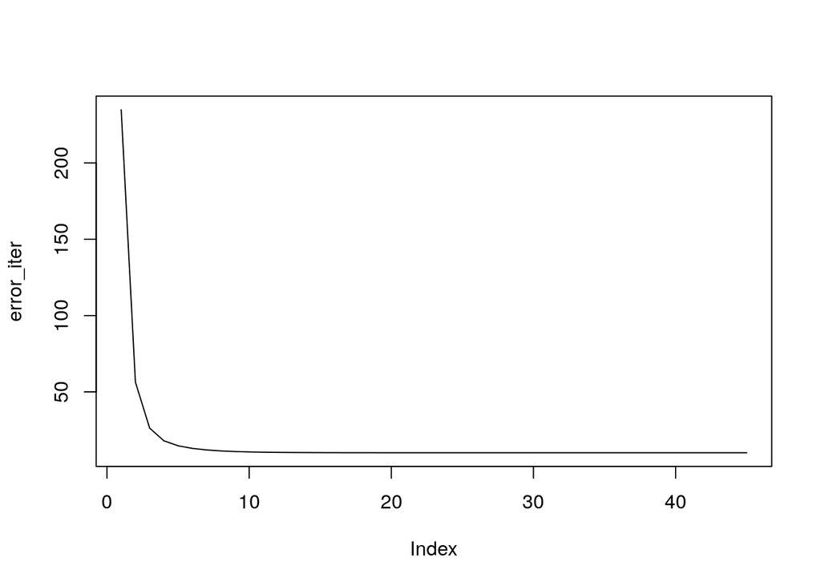

```r
## Aquí tu código, puedes usar la función "error" que definiste arriba
error_iter <- apply(salida,1,error)
plot(error_iter,type='l')
```

## Checa con lm

**Pregunta**: ¿Obtienes los mismos coeficientes *beta* si usas, por ejemplo, la función *lm*?

```r
mod_1 <- lm(grasacorp ~  estatura +  abdomen + muñeca + rodilla, data = dat_ent)
beta <- coef(mod_1)
beta
```

```
## (Intercept)    estatura     abdomen      muñeca     rodilla
##  19.2991225  -0.5417908   7.3910342  -1.3588801   0.1551511
```

### Parte 4: Evalúa con muestra de prueba

**Pregunta**: ¿cuál es el error en muestra de prueba? ¿cómo se compara con el error de entrenamiento?

Eevaluamos con la muestra de prueba:

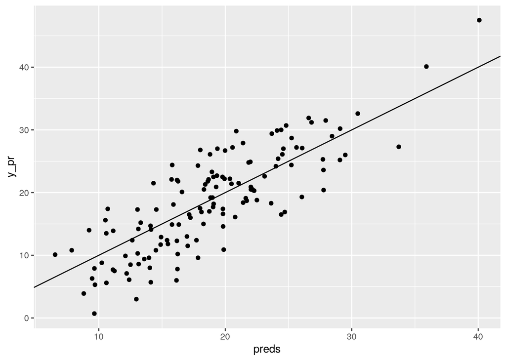

```r
calcular_preds <- function(x, beta){
  as.matrix(cbind(1, x)) %*% beta
}
beta <- salida[n,]## pon aquí los valores que encontraste
preds <- calcular_preds(x_pr, beta)
# grafica predicciones vs observados
qplot(x = preds, y = y_pr) + geom_abline(intercept = 0, slope = 1)
```

```r
error_prueba <- mean((y_pr - preds)^2)
sqrt(error_prueba)
```

```
## [1] 4.563622
```

Este número podemos interpretarlo en la escala de la variable que queremos predecir (está en porcentaje).

También podemos evaluar otro tipo de errores que pueden interpretarse más fácilmente, por ejemplo, la media del las diferencias en valores absolutos:

```r
mean(abs(y_pr - preds))
```

```
## [1] 3.854481
```

**Pregunta**: ¿Cómo se compara este error con la variación que existe en la variable grasa corporal? Es mayor la varianza contra el error de prueba

```r
sqrt(var(bodyfat$grasacorp))
```

```
## [1] 8.36874
```